# TP 2 : Arbres

Author

Sarah Matoub

Published

September 28, 2023

## Mesure d’homogénéité en régression

Dans le contexte de la régression, où l’objectif est de prédire une valeur numérique plutôt que de classer des données en catégories, une mesure d’homogénéité couramment utilisée est **l’erreur quadratique moyenne (Mean Squared Error - MSE)**.

La MSE est une mesure de la distance entre les valeurs prédites et les valeurs réelles,elle calcule la moyenne des carrés des erreurs entre les valeurs prédites et les valeurs réelles.

Plus la MSE est faible, plus le modèle de régression est précis, car cela signifie que les prédictions sont proches des valeurs réelles.

Elle est définie par l’équation :

$$MSE = \frac{1}{n} \sum_{i=1}^{n} (y_i - \hat{y}_i)^2$$

où :

$n$ est la taille de l’échantillon.

$y_i$ est la valeur réelle de la cible pour l’échantillon $i$.

$\hat{y}_i$ est la valeur prédite de la cible pour l’échantillon $i$.

C’est une mesure d’homogénéité appropriée pour évaluer la performance des modèles de régression, car elle quantifie la précision des prédictions en termes d’erreurs entre les valeurs prédites et les valeurs réelles. Elle est largement utilisée en régression en raison de sa pertinence et de sa facilité d’interprétation.

Dans la suite de ce TP nous allons considérer le cas de la classification.

## Classification avec les arbres

Avec scikit-learn on peut construire des arbres de décision grâce au package tree. On obtient un classifieur avec **tree.DecisionTreeClassifier**.

```python
from sklearn import tree
```

```python
#importer les librairies nécessaires
import os
import numpy as np
import matplotlib.pyplot as plt
import seaborn as sns
from matplotlib import rc
import random
from sklearn import tree, datasets
from sklearn.metrics import accuracy_score
from sklearn.tree import DecisionTreeClassifier
from tp_arbres_source import (rand_gauss, rand_bi_gauss, rand_tri_gauss,
                              rand_checkers, rand_clown,
                              plot_2d, frontiere)
```

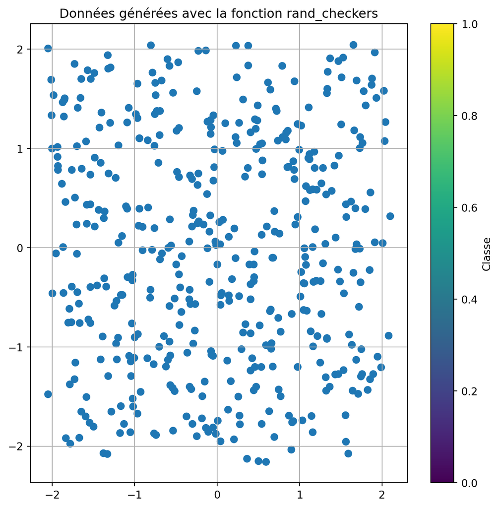

Simulation d’échantillons avec randcheckers

```python
random.seed(1)
n1 = 114
n2 = 114
n3 = 114
n4 = 114
sigma = 0.1
data4 = rand_checkers(n1, n2, n3, n4, sigma)

plt.figure(figsize=(8, 8))
plt.scatter(data4[:, 0], data4[:, 1], cmap='viridis', s=40)
plt.title('Données générées avec la fonction rand_checkers')
plt.colorbar(label='Classe')
plt.grid(True)
plt.show()
```

Nous allons à présent construire nos arbres de décision à l’aide des critères de l’entropie et l’indice de gini, avec l’attribu `criterion`:

```python
dt_entropy = tree.DecisionTreeClassifier(criterion="gini")
dt_gini = tree.DecisionTreeClassifier(criterion="entropy")

data = rand_checkers(n1=114, n2=114, n3=114, n4=114, sigma=0.1)
n_samples = len(data)
X = data[:, :2] #X_train
Y = data[:,2].astype(int)  #and careful with the type (cast to int)

dt_gini.fit(X, Y)
dt_entropy.fit(X, Y)
print("Gini criterion") #calcule les performances du score sur les données d'apprentissage
print(dt_gini.get_params())
print(dt_gini.score(X, Y))

print("Entropy criterion")
print(dt_entropy.get_params())
print(dt_entropy.score(X, Y))
```

```
Gini criterion
{'ccp_alpha': 0.0, 'class_weight': None, 'criterion': 'entropy', 'max_depth': None, 'max_features': None, 'max_leaf_nodes': None, 'min_impurity_decrease': 0.0, 'min_samples_leaf': 1, 'min_samples_split': 2, 'min_weight_fraction_leaf': 0.0, 'random_state': None, 'splitter': 'best'}
1.0
Entropy criterion
{'ccp_alpha': 0.0, 'class_weight': None, 'criterion': 'gini', 'max_depth': None, 'max_features': None, 'max_leaf_nodes': None, 'min_impurity_decrease': 0.0, 'min_samples_leaf': 1, 'min_samples_split': 2, 'min_weight_fraction_leaf': 0.0, 'random_state': None, 'splitter': 'best'}
1.0
```

Après avoir examiné les erreurs pour les indices de Gini et d’entropie sur les données d’entraînement, nous obtenons une valeur de 0 pour les deux. Cela s’explique par le fait que les échantillons que nous utilisons pour les variables à prédire sont les mêmes que ceux que nous utilisons pour les observations. En conséquence, l’algorithme apprend de manière très précise à partir de cet échantillon. Il est possible que l’algorithme s’arrête automatiquement lorsque la valeur d’erreur atteint ce seuil de 0 (en l’occurrence, 1 dans le cas d’un score parfait), car il considère que la performance est optimale à ce stade.

### Question 2

Nous allons créer deux courbes illustrant l’évolution du pourcentage d’erreurs en fonction de la profondeur maximale de l’arbre, l’une pour le critère Gini et l’autre pour l’entropie:

```
Best depth for Entropy:  12
Best accuracy with Entropy:  0.9665178571428571
Best depth for Gini:  12
Best accuracy with Gini:  0.9933035714285714
```

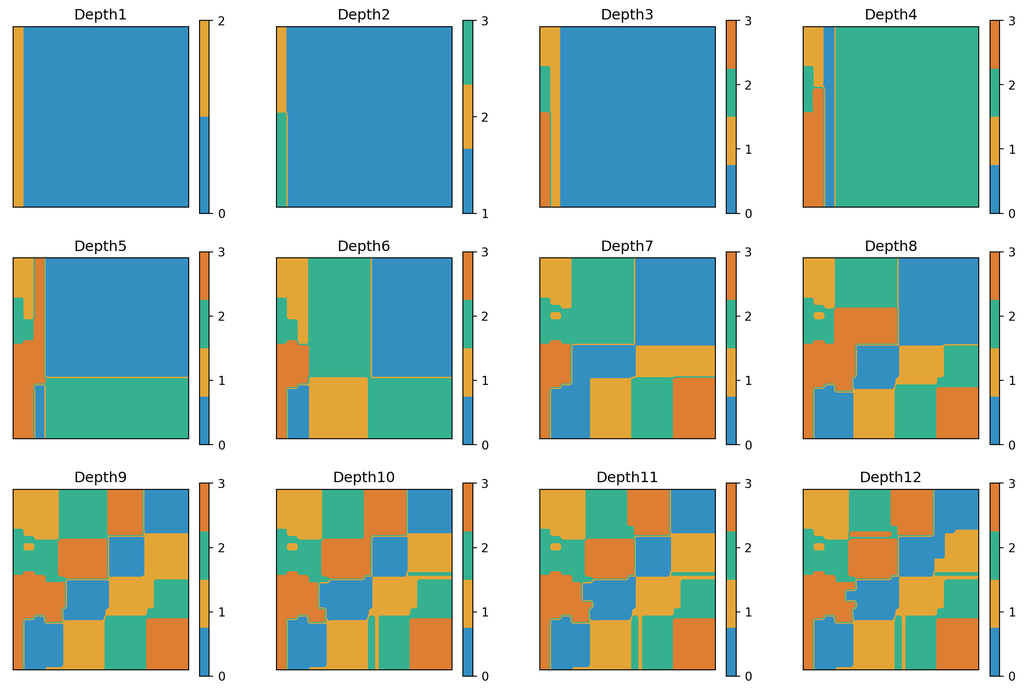

Evolution du pourcentage d’erreurs en fonction de la profondeur maximale

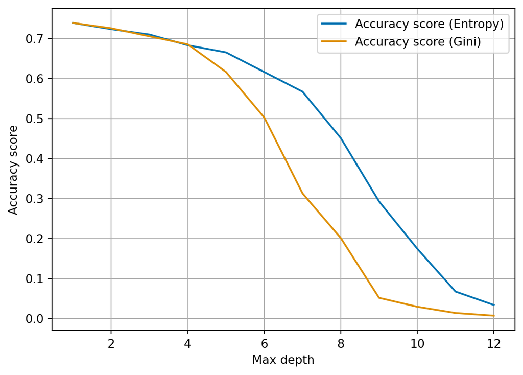

```python
random.seed(1)
dmax = 12
scores_entropy = np.zeros(dmax)
scores_gini = np.zeros(dmax)

best_depth_entropy = None
best_score_entropy = 0.0

best_depth_gini = None
best_score_gini = 0.0


plt.figure(figsize=(15, 10))
for i in range(dmax):
    # Arbre de décision avec le critère entropy
    dt_entropy = tree.DecisionTreeClassifier(criterion="entropy", max_depth = i + 1, random_state = 0)
    dt_entropy.fit(X, Y)
    Y_pred_entropy = dt_entropy.predict(X)
    scores_entropy[i] = accuracy_score(Y, Y_pred_entropy)
    if scores_entropy[i] > best_score_entropy:
        best_score_entropy = scores_entropy[i]
        best_depth_entropy = i + 1

    # Arbre de décision avec le critère gini
    dt_gini = tree.DecisionTreeClassifier(criterion="gini", max_depth = i + 1, random_state = 0)
    dt_gini.fit(X, Y)
    Y_pred_gini = dt_gini.predict(X)
    scores_gini[i] = accuracy_score(Y, Y_pred_gini)
    if scores_gini[i] > best_score_gini:
        best_score_gini = scores_gini[i]
    best_depth_gini = i + 1

    plt.subplot(3, 4, i + 1)
    frontiere(lambda x: dt_gini.predict(x.reshape((1, -1))), X, Y, step=50, samples=False)
    plt.title(f'Depth{ i + 1 }')
plt.draw()


plt.figure()
plt.plot(range(1, dmax + 1), 1 - scores_entropy, label="Accuracy score (Entropy)")
plt.plot(range(1, dmax + 1), 1 - scores_gini, label="Accuracy score (Gini)")
plt.xlabel("Max depth")
plt.ylabel("Accuracy score")
plt.legend()
plt.grid(True)
plt.draw()

print("Best depth for Entropy: ", best_depth_entropy)
print("Best accuracy with Entropy: ", best_score_entropy)
print("Best depth for Gini: ", best_depth_gini)
print("Best accuracy with Gini: ", best_score_gini)
```

Il est également important de noter qu’en utilisant un arbre avec une profondeur faible, l’erreur est considérablement élevée. Cela est dû au fait que, dans des cas où les données sont bien réparties et où l’on ne peut effectuer qu’une seule coupe, nous obtenons deux classes extrêmement hétérogènes.

### Question 3

Nous allons présenter la classification obtenue en utilisant la profondeur qui minimise le pourcentage d’erreurs basées sur l’entropie, en utilisant les fonctions `plot_2d()` et `frontiere()` du fichier source :

```
Best scores with entropy criterion:  0.9665178571428571
```

Classification obtenue avec la meilleur profondeur

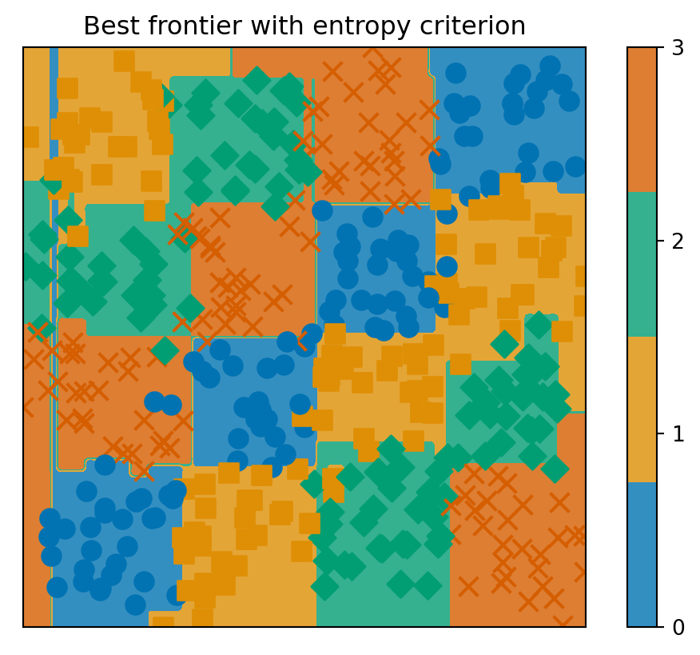

```python
random.seed(1234)
# Créer un arbre de décision avec la meilleure profondeur pour l'entropie
best_tree_entropy = DecisionTreeClassifier(
    criterion="entropy", max_depth=best_depth_entropy, random_state=0)
best_tree_entropy.fit(X, Y)
# Afficher la classification obtenue avec la profondeur optimale (Entropy)
plt.figure(figsize=(8, 8))
plt.figure()
frontiere(lambda x: dt_entropy.predict(x.reshape((1, -1))), X, Y, step=100,
          samples=True)
plt.title("Best frontier with entropy criterion")
plt.draw()
print("Best scores with entropy criterion: ", dt_entropy.score(X, Y))
```

On voit que la plupart des données d’apprentissage sont correctement classées, ce qui témoigne d’une bonne performance globale du modèle. Cependant, il est important de noter que les frontières de décision obtenues sont assez complexes. Ceci est principalement dû au fait qu’une profondeur maximale élevée signifie que nous autorisons une découpe très fine de l’espace, ce qui peut conduire à des frontières de décision complexes et détaillées.

### Question 4

Nous allons utiliser la fonction `export_graphviz()` du module `tree` pour exporter le graphique de l’arbre obtenu dans la question précédente au format PDF.

```python
from sklearn import tree
from sklearn.tree import DecisionTreeClassifier
from sklearn.tree import export_graphviz
import graphviz
from graphviz import Source

import os
os.environ["PATH"] += os.pathsep + 'D:/Program Files (x86)/Graphviz2.38/bin/'

best_tree_entropy = DecisionTreeClassifier(criterion="entropy", max_depth=best_depth_entropy, random_state=0)
best_tree_entropy.fit(X, Y)
# On exporte l'arbre au format DOT
donnes = export_graphviz(best_tree_entropy)
# On crée un objet Graphviz à partir du fichier DOT
graph = graphviz.Source(donnes)
graph.render("best_tree_entropy", format = "pdf")
```

```
'best_tree_entropy.pdf'
```

La lecture d’un arbre de décision est assez intuitive et suit un schéma hiérarchique. Il commence par un noeud appelé “la racine” , qui représente le tout premier point de décision de l’arbre. À partir de la racine, il y a généralement deux noeuds enfants. Chaque noeud qui n’est pas une feuille a lui-même deux noeuds enfants, et cela se répète jusqu’à ce que nous atteignions les noeuds terminaux, également appelés “feuilles”, où les décisions sont prises.

La manière de lire un arbre de décision est la suivante :

- Si la condition spécifiée au niveau d’un noeud est satisfaite pour une observation donnée, nous suivons la branche de gauche de ce noeud. En revanche, si la condition n’est pas satisfaite, nous empruntons la branche de droite. En suivant ces branches de noeud en noeud, de la racine aux feuilles, nous finissons par atteindre une feuille qui indique la décision ou la prédiction finale basée sur les conditions remplies par l’observation.

### Question 5

Nous allons générer un nouvel ensemble de données contenant n = 160 échantillons, répartis en 40 exemplaires de chaque classe à l’aide de la fonction `rand_checkers()`. Ensuite, nous évaluerons les arbres de décision préalablement entraînés en calculant la proportion d’erreurs commises sur cet échantillon de test:

```
Proportion d'erreurs sur le nouvel échantillon (Entropy): 12.50%
Proportion d'erreurs sur le nouvel échantillon (Gini): 0.00%
Proportion d'erreurs sur le nouvel échantillon (Entropy): 12.50%
Proportion d'erreurs sur le nouvel échantillon (Gini): 0.00%
```

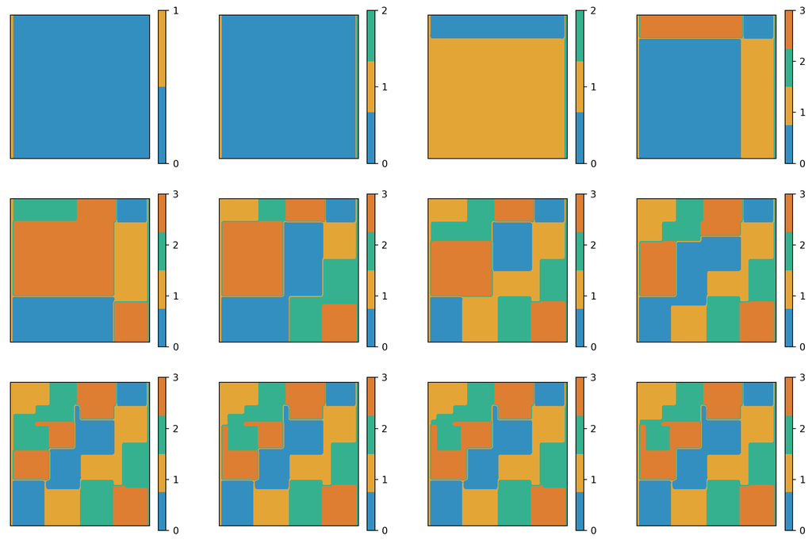

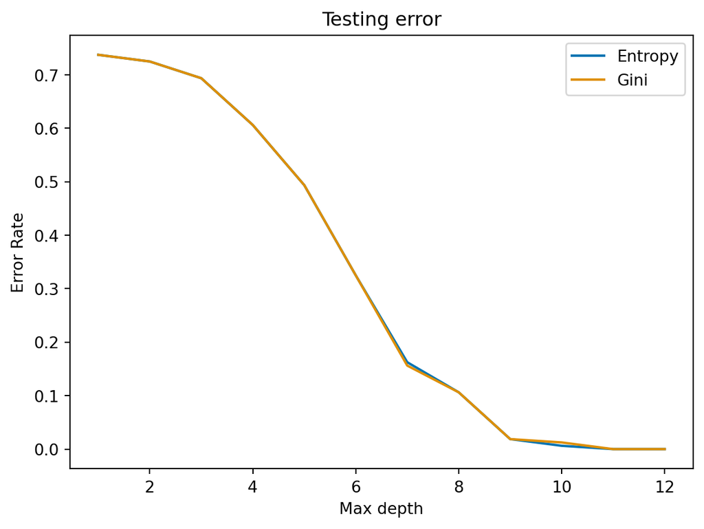

```python
# Créer un nouvel échantillon de test avec 160 données (40 de chaque classe)
random.seed(1)
new_data = rand_checkers(n1=40, n2=40, n3=40, n4=40, sigma=0.1)

# Séparer les caractéristiques et les étiquettes
X_new = new_data[:, :2]
Y_new = new_data[:, 2].astype(int)

# Évaluer les modèles sur le nouvel échantillon de test
error_rate_entropy = 1 - best_tree_entropy.score(X_new, Y_new)

best_tree_gini = DecisionTreeClassifier(criterion="gini", max_depth=best_depth_gini, random_state=0)
best_tree_gini.fit(X_new, Y_new)

error_rate_gini = 1 - best_tree_gini.score(X_new, Y_new)

print("Proportion d'erreurs sur le nouvel échantillon (Entropy): {:.2f}%".format(error_rate_entropy * 100))
print("Proportion d'erreurs sur le nouvel échantillon (Gini): {:.2f}%".format(error_rate_gini * 100))

dmax = 12
scores_entropy = np.zeros(dmax)
scores_gini = np.zeros(dmax)
plt.figure(figsize=(15, 10))

for i in range(dmax):

    # Créer un arbre de décision avec une profondeur maximale variable (entropy)
    dt_entropy = DecisionTreeClassifier(criterion="entropy", max_depth=i + 1)
    dt_entropy.fit(X_new, Y_new)
    scores_entropy[i] = 1 - dt_entropy.score(X_new, Y_new)

    dt_gini = DecisionTreeClassifier(criterion="gini", max_depth = i + 1)
    dt_gini.fit(X_new, Y_new)
    scores_gini[i] = 1 - dt_gini.score(X_new, Y_new)

    plt.subplot(3, 4, i + 1)
    frontiere(lambda x: dt_gini.predict(x.reshape((1, -1))), X_new, Y_new, step=50, samples=False)

plt.figure()
plt.plot(range(1, dmax + 1), scores_entropy, label="Entropy")
plt.plot(range(1, dmax + 1), scores_gini, label="Gini")
plt.xlabel('Max depth')
plt.ylabel('Error Rate')
plt.title("Testing error")
plt.legend()
plt.show()

print("Proportion d'erreurs sur le nouvel échantillon (Entropy): {:.2f}%".format(error_rate_entropy * 100))
print("Proportion d'erreurs sur le nouvel échantillon (Gini): {:.2f}%".format(error_rate_gini * 100))
```

### Question 6

Nous allons reprendre ce qui a été fait précédement avec le dataset **DIGITS** :

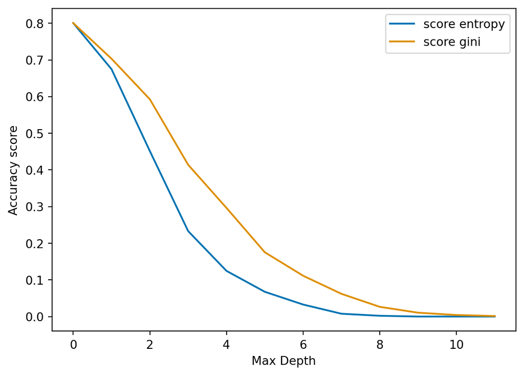

Pourcentage d’erreur en fonction de la profondeur maximale sur les données d’entrainement

```python
from sklearn import datasets
from sklearn.model_selection import train_test_split
# Import the digits dataset
digits = datasets.load_digits()

n_samples = len(digits.data)
d = digits.images.reshape((n_samples, -1))
# Diviser l'ensemble de données en ensembles d'entraînement et de test (80% - 20%)

X_train, X_test, Y_train, Y_test = train_test_split(d,
digits.target, test_size = 0.2, shuffle=False)

dmax = 12
scores_entropy = np.zeros(dmax)
scores_gini = np.zeros(dmax)

for i in range(dmax):
    # Arbre de décision pour l'entropie
    dt_entropy = DecisionTreeClassifier(criterion="entropy", max_depth = i + 1)
    dt_entropy.fit(X_train, Y_train)
    scores_entropy[i] = 1 - dt_entropy.score(X_train, Y_train)

    #Arbre de décision pour gini
    dt_gini =  DecisionTreeClassifier(criterion="gini", max_depth = i + 1)
    dt_gini.fit(X_train, Y_train)
    scores_gini[i] = 1 - dt_gini.score(X_train, Y_train)

plt.figure()
plt.plot(scores_entropy, label = "score entropy")
plt.plot(scores_gini, label = "score gini")
plt.legend()
plt.xlabel("Max Depth")
plt.ylabel("Accuracy score")
plt.draw()
```

Evaluons maintenant la performance des arbres de décision préalablement entraînés en calculant la proportion d’erreurs qu’ils commettent sur l’échantillon de test :

```
Entropy criterion scores :  [0.8        0.72777778 0.52777778 0.32777778 0.25       0.23333333
 0.21666667 0.24166667 0.20833333 0.21388889 0.23333333 0.20555556]
Gini criterion scores :  [0.80555556 0.69166667 0.59166667 0.45       0.375      0.27222222
 0.24722222 0.21666667 0.21944444 0.21666667 0.18611111 0.21388889]
```

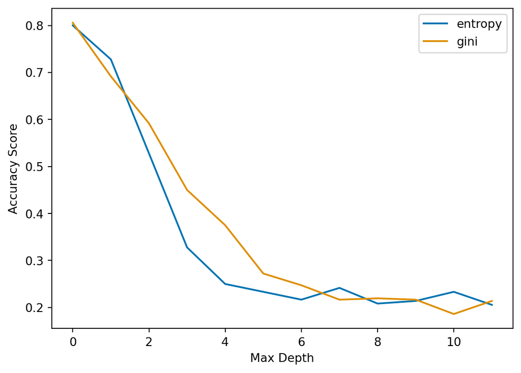

Pourcentage d’erreur en fonction de la profondeur maximale sur les données de test

```python
dmax = 12
scores_entropy = np.zeros(dmax)
scores_gini = np.zeros(dmax)

for i in range(dmax):
    dt_entropy = tree.DecisionTreeClassifier(criterion="entropy", max_depth = i + 1)
    dt_entropy.fit(X_train,Y_train)
    scores_entropy[i] = 1 - dt_entropy.score(X_test, Y_test)

    dt_gini = tree.DecisionTreeClassifier(criterion="gini", max_depth = i+1)
    dt_gini.fit(X_train,Y_train)
    scores_gini[i] = 1 - dt_gini.score(X_test,Y_test)


plt.figure()
plt.plot(scores_entropy, label="entropy")
plt.plot(scores_gini, label="gini")
plt.legend()
plt.xlabel("Max Depth")
plt.ylabel("Accuracy Score")
plt.draw()
print("Entropy criterion scores : ", scores_entropy)
print("Gini criterion scores : ", scores_gini)
```

Nous allons exporter le graphique de l’arbre obtenu comme nous l’avions fait à la question 4.

```python
dot_data2 = tree.export_graphviz(dt_entropy, out_file=None)
graph = graphviz.Source(dot_data2)
graph.render("Plots\Arbre_question6", format="pdf")
```

### Question 7

```python
from sklearn.model_selection import cross_val_score

# Profondeurs maximales à tester
max_depths = np.arange(1, 16, 1)

# scores de validation croisée
cv_scores = []

# Tester chaque profondeur maximale
for depth in max_depths:
    # Initialiser et entraîner l'arbre de décision avec le critère d'Entropy
    tree_classifier = DecisionTreeClassifier(criterion="entropy", max_depth=depth, random_state=0)

    # Effectuer une validation croisée avec 5 plis
    scores = cross_val_score(tree_classifier, X, Y, cv=5)

    # Calculer la moyenne des scores de validation croisée
    mean_score = scores.mean()

    # Ajouter le score moyen à la liste des scores
    cv_scores.append(mean_score)

# Trouver la meilleure profondeur maximale avec le score le plus élevé
best_depth_index = cv_scores.index(max(cv_scores))
best_depth = max_depths[best_depth_index]


for depth, score in zip(max_depths, cv_scores):
    print("Profondeur maximale = {}, Score de validation croisée moyen = {:.4f}".format(depth, score))

print("Meilleure profondeur maximale (Entropy) = {}, Score de validation croisée moyen = {:.4f}".format(best_depth, max(cv_scores)))
```

```
Profondeur maximale = 1, Score de validation croisée moyen = 0.2455
Profondeur maximale = 2, Score de validation croisée moyen = 0.2590
Profondeur maximale = 3, Score de validation croisée moyen = 0.2679
Profondeur maximale = 4, Score de validation croisée moyen = 0.2925
Profondeur maximale = 5, Score de validation croisée moyen = 0.3215
Profondeur maximale = 6, Score de validation croisée moyen = 0.3549
Profondeur maximale = 7, Score de validation croisée moyen = 0.4686
Profondeur maximale = 8, Score de validation croisée moyen = 0.5446
Profondeur maximale = 9, Score de validation croisée moyen = 0.6780
Profondeur maximale = 10, Score de validation croisée moyen = 0.7384
Profondeur maximale = 11, Score de validation croisée moyen = 0.7675
Profondeur maximale = 12, Score de validation croisée moyen = 0.7764
Profondeur maximale = 13, Score de validation croisée moyen = 0.7832
Profondeur maximale = 14, Score de validation croisée moyen = 0.7922
Profondeur maximale = 15, Score de validation croisée moyen = 0.7967
Meilleure profondeur maximale (Entropy) = 15, Score de validation croisée moyen = 0.7967
```

### Question 8

Nous allons afficher la courbe d’apprentissage (en : learning curve) pour les arbres de décisions sur le même jeu de données :

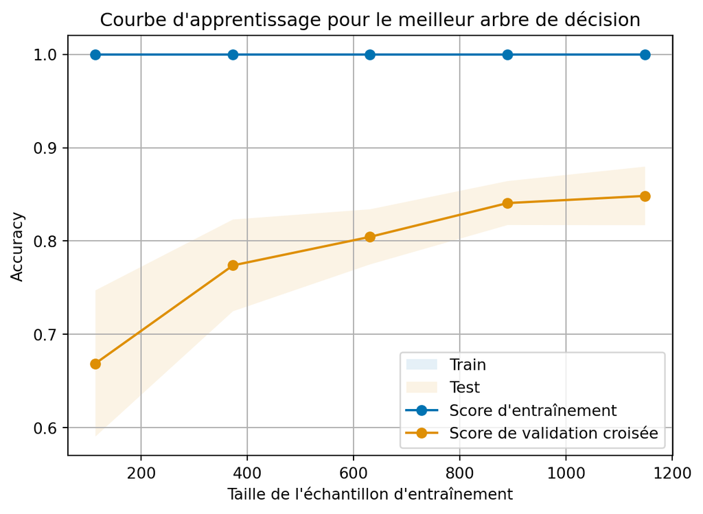

Courbe d’apprentissage pour le meilleur arbre de décision

```python
from sklearn.model_selection import learning_curve
from sklearn.model_selection import train_test_split

# Charger l'ensemble de données digits
digits = datasets.load_digits()
X = digits.data
Y = digits.target

# Diviser l'ensemble de données en ensembles d'entraînement (80%) et de test (20%)
X_train, X_test, Y_train, Y_test = train_test_split(X, Y, test_size=0.2, random_state=0)

# Créer un classificateur d'arbre de décision avec la meilleure profondeur
dt = DecisionTreeClassifier(criterion='entropy', max_depth=best_depth)

# Calculer la courbe d'apprentissage
n_samples, train_scores, test_scores = learning_curve(dt, X_train, Y_train, cv=5)

# Calculer les moyennes et les écarts types des scores
train_scores_mean = np.mean(train_scores, axis=1)
train_scores_std = np.std(train_scores, axis=1)
test_scores_mean = np.mean(test_scores, axis=1)
test_scores_std = np.std(test_scores, axis=1)

# Tracer la courbe d'apprentissage
plt.figure()
plt.grid()
plt.fill_between(n_samples, train_scores_mean - 1.96 * train_scores_std,
                 train_scores_mean + 1.96 * train_scores_std, alpha=0.1, label="Train")
plt.fill_between(n_samples, test_scores_mean - 1.96 * test_scores_std,
                 test_scores_mean + 1.96 * test_scores_std, alpha=0.1, label="Test")
plt.plot(n_samples, train_scores_mean, 'o-', label="Score d'entraînement")
plt.plot(n_samples, test_scores_mean, 'o-', label="Score de validation croisée")
plt.legend(loc="lower right")
plt.xlabel("Taille de l'échantillon d'entraînement")
plt.ylabel("Accuracy")
plt.title("Courbe d'apprentissage pour le meilleur arbre de décision")
plt.show()
```